# Unit Root

**Classic Unit Root Test:**

**ADF Test:**

ADF test is made with using function from own GIT reposotory:

```r
if(!"devtools" %in% installed.packages()) install.packages("devtools")

UnitRootGIT='https://raw.githubusercontent.com/kamilbanas85/Unit-Root-Test---ADF/master/UnitRootFunctions.R'

devtools::source_url(UnitRootGIT)
```

The ADFUnitRoot function based on urca::ur.df function (https://cran.r-project.org/web/packages/urca/urca.pdf).

```r
ADFUnitRoot( TS or XTS object,
             type = c("trend","drift","none",
             selectlags = c("AIC","BIC","Fixed"),
             LagsNumber = 30)
```

**Example**:

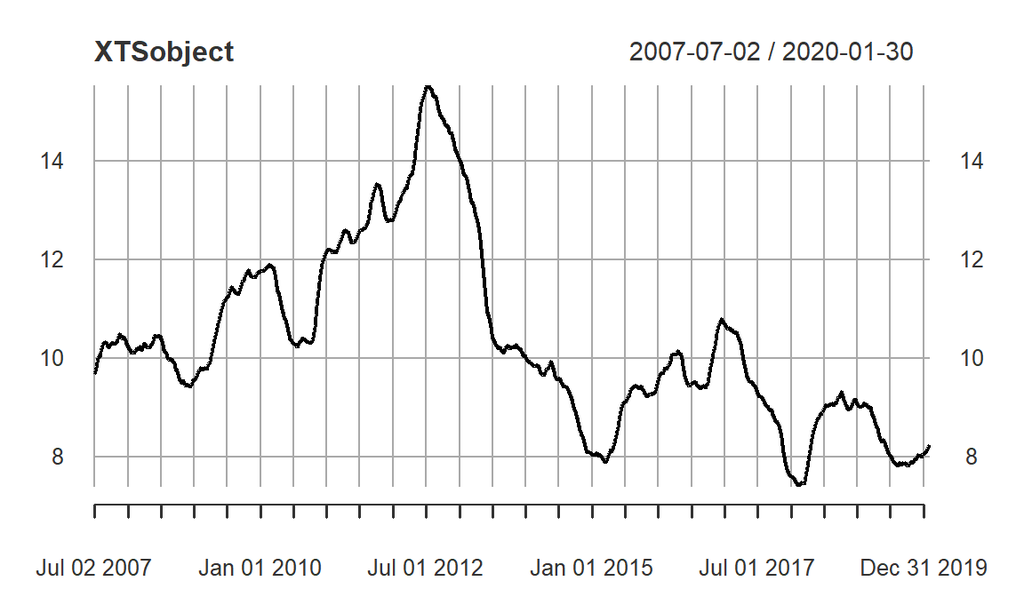

```r
plot(XTSobject)
```

**ADF test with trend and drift:**

```r
   ADFUnitRoot( XTSobject,
                type = "trend",
                selectlags = "AIC",
                LagsNumber = 30)
```

$tau = -2.4082 \ >\ Cr\ => \$ Time Series has got unit root  
$phi3 =\ 3.0222 \ <\ Cr\ => \$ Null is true $\ => \gamma = a_2 = 0$  
$phi2 =\ 2.0330 \ <\ Cr\ => \$ Null is true $\ => a_0 = \gamma = a_2 = 0$  
Coefficients are insignificant, so regression equation is misspecified. Next test have to be made.

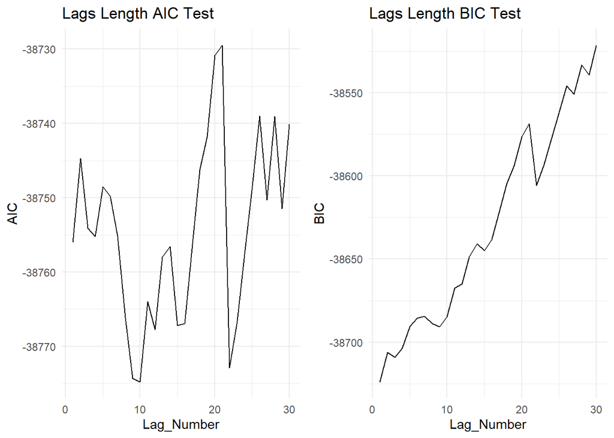

```
##
## ###############################################
## # Augmented Dickey-Fuller Test Unit Root Test #
## ###############################################
##
## Test regression trend
##
##
## Call:
## lm(formula = z.diff ~ z.lag.1 + 1 + tt + z.diff.lag)
##
## Residuals:
##       Min        1Q    Median        3Q       Max
## -0.017363 -0.002017  0.000030  0.002033  0.017054
##
## Coefficients:
##                Estimate Std. Error t value Pr(>|t|)
## (Intercept)   9.820e-04  4.076e-04   2.409 0.016020 *
## z.lag.1      -7.877e-05  3.273e-05  -2.406 0.016146 *
## tt           -7.675e-08  4.565e-08  -1.681 0.092771 .
## z.diff.lag1   9.548e-01  1.482e-02  64.435  < 2e-16 ***
## z.diff.lag2  -8.040e-02  2.049e-02  -3.925 8.82e-05 ***
## z.diff.lag3   2.553e-02  2.051e-02   1.244 0.213439
## z.diff.lag4   2.511e-02  2.049e-02   1.226 0.220389
## z.diff.lag5  -1.148e-02  2.047e-02  -0.561 0.575151
## z.diff.lag6  -8.644e-03  2.046e-02  -0.422 0.672715
## z.diff.lag7   8.273e-02  2.044e-02   4.046 5.29e-05 ***
## z.diff.lag8  -8.391e-02  2.038e-02  -4.117 3.91e-05 ***
## z.diff.lag9  -3.854e-03  2.032e-02  -0.190 0.849562
## z.diff.lag10  5.881e-02  2.031e-02   2.896 0.003799 **
## z.diff.lag11 -5.207e-02  2.031e-02  -2.563 0.010401 *
## z.diff.lag12  5.640e-02  2.033e-02   2.775 0.005546 **
## z.diff.lag13 -3.855e-02  2.035e-02  -1.895 0.058173 .
## z.diff.lag14  9.620e-02  2.034e-02   4.729 2.32e-06 ***
## z.diff.lag15 -9.913e-02  2.034e-02  -4.874 1.13e-06 ***
## z.diff.lag16  4.152e-02  2.034e-02   2.041 0.041331 *
## z.diff.lag17 -8.532e-03  2.035e-02  -0.419 0.674983
## z.diff.lag18 -1.874e-02  2.033e-02  -0.922 0.356590
## z.diff.lag19  4.128e-02  2.031e-02   2.032 0.042215 *
## z.diff.lag20 -4.358e-02  2.030e-02  -2.147 0.031884 *
```

[output cut: 9 more lines]

```
## ---
## Signif. codes:  0 '***' 0.001 '**' 0.01 '*' 0.05 '.' 0.1 ' ' 1
##
## Residual standard error: 0.003452 on 4530 degrees of freedom
## Multiple R-squared:  0.9105, Adjusted R-squared:  0.9099
## F-statistic:  1486 on 31 and 4530 DF,  p-value: < 2.2e-16
##
##
## Value of test-statistic is: -2.4065 2.0355 3.0243
##
## Critical values for test statistics:
##       1pct  5pct 10pct
## tau3 -3.96 -3.41 -3.12
## phi2  6.09  4.68  4.03
## phi3  8.27  6.25  5.34
```

**ADF test with drift:**

```r
ADFUnitRoot( XTSobject,
             type = "drift",
             selectlags = "BIC",
             LagsNumber = 30)
```

$tau = -1.8032 \ >\ Cr\ => \$ Time Series has got unit root  
$phi1 =\ 1.6530 \ <\ Cr\ => \$ Null is true $\ => \gamma = a_2 = 0$

Coefficients are insignificant, so regression equation is misspecified. Next test have to be made.

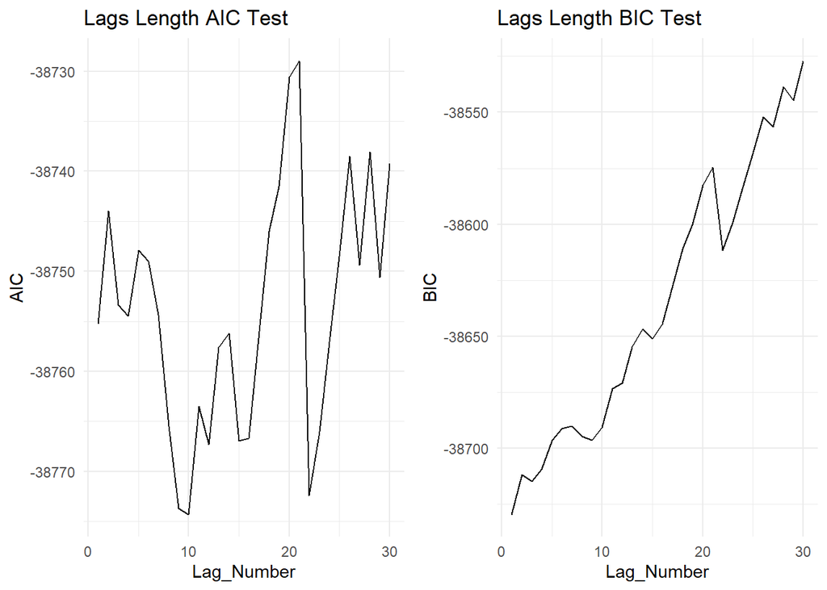

```
##
## ###############################################
## # Augmented Dickey-Fuller Test Unit Root Test #
## ###############################################
##
## Test regression drift
##
##
## Call:
## lm(formula = z.diff ~ z.lag.1 + 1 + z.diff.lag)
##
## Residuals:
##       Min        1Q    Median        3Q       Max
## -0.017381 -0.002022  0.000024  0.002023  0.017070
##
## Coefficients:
##                Estimate Std. Error t value Pr(>|t|)
## (Intercept)   5.089e-04  2.949e-04   1.726 0.084491 .
## z.lag.1      -5.024e-05  2.800e-05  -1.795 0.072791 .
## z.diff.lag1   9.554e-01  1.482e-02  64.481  < 2e-16 ***
## z.diff.lag2  -8.040e-02  2.049e-02  -3.924 8.85e-05 ***
## z.diff.lag3   2.557e-02  2.052e-02   1.246 0.212789
## z.diff.lag4   2.510e-02  2.049e-02   1.225 0.220740
## z.diff.lag5  -1.146e-02  2.048e-02  -0.560 0.575636
## z.diff.lag6  -8.611e-03  2.047e-02  -0.421 0.673948
## z.diff.lag7   8.274e-02  2.045e-02   4.047 5.28e-05 ***
## z.diff.lag8  -8.392e-02  2.039e-02  -4.117 3.91e-05 ***
## z.diff.lag9  -3.832e-03  2.032e-02  -0.189 0.850450
## z.diff.lag10  5.882e-02  2.031e-02   2.896 0.003800 **
## z.diff.lag11 -5.206e-02  2.032e-02  -2.562 0.010430 *
## z.diff.lag12  5.641e-02  2.033e-02   2.774 0.005554 **
## z.diff.lag13 -3.857e-02  2.035e-02  -1.895 0.058119 .
## z.diff.lag14  9.622e-02  2.035e-02   4.730 2.32e-06 ***
## z.diff.lag15 -9.917e-02  2.034e-02  -4.875 1.13e-06 ***
## z.diff.lag16  4.154e-02  2.035e-02   2.041 0.041260 *
## z.diff.lag17 -8.533e-03  2.035e-02  -0.419 0.674993
## z.diff.lag18 -1.874e-02  2.033e-02  -0.922 0.356822
## z.diff.lag19  4.130e-02  2.032e-02   2.033 0.042131 *
## z.diff.lag20 -4.360e-02  2.031e-02  -2.147 0.031823 *
## z.diff.lag21  1.371e-01  2.032e-02   6.748 1.69e-11 ***
## z.diff.lag22 -1.320e-01  2.038e-02  -6.476 1.04e-10 ***
## z.diff.lag23  5.151e-02  2.044e-02   2.521 0.011746 *
## z.diff.lag24 -4.498e-02  2.045e-02  -2.200 0.027886 *
## z.diff.lag25  4.353e-02  2.045e-02   2.128 0.033383 *
## z.diff.lag26 -5.859e-02  2.045e-02  -2.865 0.004191 **
## z.diff.lag27  3.861e-02  2.046e-02   1.887 0.059254 .
## z.diff.lag28  7.094e-02  2.043e-02   3.472 0.000522 ***
## z.diff.lag29 -7.218e-02  1.477e-02  -4.887 1.06e-06 ***
## ---
## Signif. codes:  0 '***' 0.001 '**' 0.01 '*' 0.05 '.' 0.1 ' ' 1
##
## Residual standard error: 0.003453 on 4531 degrees of freedom
## Multiple R-squared:  0.9104, Adjusted R-squared:  0.9098
## F-statistic:  1535 on 30 and 4531 DF,  p-value: < 2.2e-16
##
##
## Value of test-statistic is: -1.7946 1.6392
##
## Critical values for test statistics:
##       1pct  5pct 10pct
## tau2 -3.43 -2.86 -2.57
## phi1  6.43  4.59  3.78
```

**ADF test without constant:**

```r
ADFUnitRoot( XTSobject,
             type = "none",
             selectlags = "AIC",
             LagsNumber = 30)
```

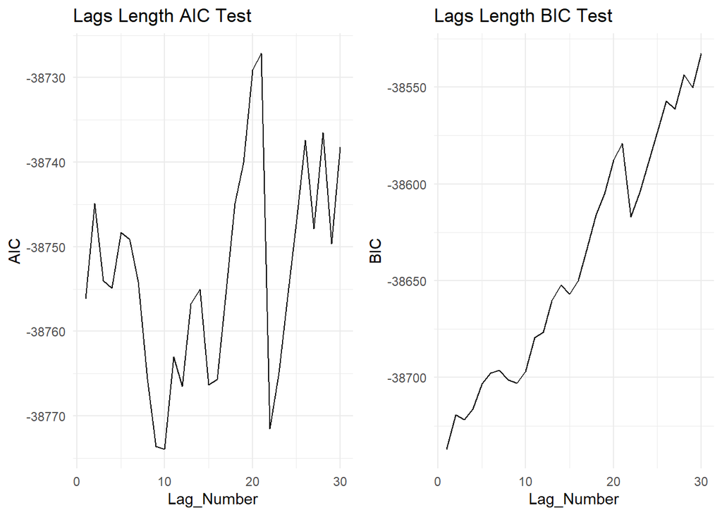

```
##
## ###############################################
## # Augmented Dickey-Fuller Test Unit Root Test #
## ###############################################
##
## Test regression none
##
##
## Call:
## lm(formula = z.diff ~ z.lag.1 - 1 + z.diff.lag)
##
## Residuals:
##       Min        1Q    Median        3Q       Max
## -0.017453 -0.001995  0.000046  0.002052  0.017099
##
## Coefficients:
##                Estimate Std. Error t value Pr(>|t|)
## z.lag.1      -2.663e-06  4.857e-06  -0.548 0.583483
## z.diff.lag1   9.561e-01  1.481e-02  64.535  < 2e-16 ***
## z.diff.lag2  -8.042e-02  2.050e-02  -3.924 8.85e-05 ***
## z.diff.lag3   2.557e-02  2.052e-02   1.246 0.212802
## z.diff.lag4   2.513e-02  2.050e-02   1.226 0.220266
## z.diff.lag5  -1.148e-02  2.048e-02  -0.561 0.575088
## z.diff.lag6  -8.582e-03  2.047e-02  -0.419 0.675032
## z.diff.lag7   8.273e-02  2.045e-02   4.045 5.32e-05 ***
## z.diff.lag8  -8.389e-02  2.039e-02  -4.114 3.96e-05 ***
## z.diff.lag9  -3.846e-03  2.033e-02  -0.189 0.849927
## z.diff.lag10  5.884e-02  2.032e-02   2.896 0.003797 **
## z.diff.lag11 -5.212e-02  2.032e-02  -2.564 0.010365 *
## z.diff.lag12  5.641e-02  2.034e-02   2.774 0.005561 **
## z.diff.lag13 -3.860e-02  2.035e-02  -1.897 0.057953 .
## z.diff.lag14  9.618e-02  2.035e-02   4.727 2.35e-06 ***
## z.diff.lag15 -9.919e-02  2.035e-02  -4.875 1.13e-06 ***
## z.diff.lag16  4.151e-02  2.035e-02   2.039 0.041459 *
## z.diff.lag17 -8.563e-03  2.035e-02  -0.421 0.674005
## z.diff.lag18 -1.880e-02  2.034e-02  -0.924 0.355337
## z.diff.lag19  4.129e-02  2.032e-02   2.032 0.042232 *
## z.diff.lag20 -4.369e-02  2.031e-02  -2.151 0.031513 *
## z.diff.lag21  1.370e-01  2.032e-02   6.744 1.74e-11 ***
## z.diff.lag22 -1.321e-01  2.038e-02  -6.478 1.03e-10 ***
## z.diff.lag23  5.146e-02  2.044e-02   2.518 0.011853 *
## z.diff.lag24 -4.506e-02  2.045e-02  -2.203 0.027623 *
## z.diff.lag25  4.348e-02  2.046e-02   2.125 0.033616 *
## z.diff.lag26 -5.868e-02  2.046e-02  -2.869 0.004141 **
## z.diff.lag27  3.853e-02  2.047e-02   1.883 0.059824 .
## z.diff.lag28  7.090e-02  2.044e-02   3.469 0.000527 ***
## z.diff.lag29 -7.303e-02  1.477e-02  -4.946 7.85e-07 ***
## ---
## Signif. codes:  0 '***' 0.001 '**' 0.01 '*' 0.05 '.' 0.1 ' ' 1
##
## Residual standard error: 0.003453 on 4532 degrees of freedom
## Multiple R-squared:  0.9105, Adjusted R-squared:  0.9099
## F-statistic:  1537 on 30 and 4532 DF,  p-value: < 2.2e-16
##
##
## Value of test-statistic is: -0.5483
##
## Critical values for test statistics:
##       1pct  5pct 10pct
## tau1 -2.58 -1.95 -1.62
```

**Check residuals:**

Proper number of lags sholud lead to white noise residual (http://www.econ.illinois.edu/~econ536/eTA/Stata/eTA8_Stata.html). To check it:

```r
ModelFromTest <- ADFUnitRoot( XTSobject,
                              type = "none",
                              selectlags = "AIC",
                              LagsNumber = 40)

print(urca::summary(ModelFromTest))

urca::plot(ModelFromTest)
plot(ModelFromTest@res, type = "b")
```

**KPSS Test:**

One response to the low power of ADF tests in the presence of near unit root stationarity was the test of Kwiatkowski, Phillips, Schmidt, and Shin (1992) (KPSS) http://blog.eviews.com/2019/04/seasonal-unit-root-tests.html

**KPSS test null hyphotesis: a time series is stationary around a mean or linear trend.**

```r
tseries::kpss.test(XTSobject, null = "Level", lshort = TRUE)
```

p-value < 0.01 dosn’t support null hypothesis, so null is rejected, Time Series has a unit root.

```
##
##  KPSS Test for Level Stationarity
##
## data:  XTSobject
## KPSS Level = 15.929, Truncation lag parameter = 10, p-value = 0.01
```

**Seasonal Unit Roots Tests**

https://homepage.univie.ac.at/robert.kunst/season12.pdf  
“Deterministic versus stochastic seasonal fractional integration and structural breaks”  
https://www.jalobe.com/doc/uroot.pdf  
https://homepage.univie.ac.at/robert.kunst/season12.pdf

**Three main types of seasonality in time-series processes:**

- Deterministic seasonal processes: Seasonality is constant over time. It can be described by seasonal dummy varables.
- Seasonal stochastic stationary processes: a change of a seasonal component(s) across time is/are stationary process - with ARMA model (the forecast in any given season is a function of past season values).
- Seasonal stochastic processes with a seasonal unit root - series has a seasonal unit root, it means that the seasonal component(s) change across time is/are random walk (current season = last season + WN).

The Hylleberg-Engle-Granger-Yoo (HEGY) statistics for testing the null hypothesis: seasonal unit roots exists

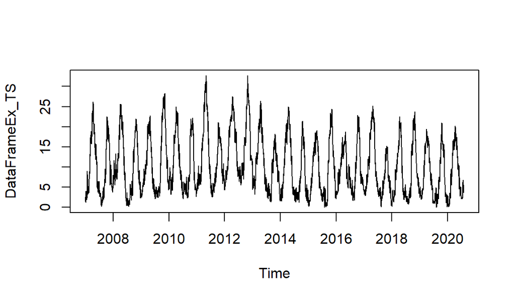

```r
plot(DataFrameEx_TS)
```

```r
uroot::hegy.test(DataFrameEx_TS,
              #  deterministic = c(0,0,0),
                 lag.method = "BIC",
                 maxlag = 20)
```

P-value < 0.01 of join F-statistic for seasonal frequency (365). The null hypothesis is rejected. Time Series is seasonal stationary.

```
##
##  HEGY test for unit roots
##
## data:  DataFrameEx_TS
##
##           statistic p-value
## t_1         -1.4483   0.522
## F_2:3        3.9176  0.0154 *
## F_4:5        0.3251  0.7303
## F_6:7        4.8132  0.0057 **
## F_8:9        2.2489  0.0956 .
## F_10:11      8.2125   1e-04 ***
## F_12:13      12.595       0 ***
## F_14:15      11.902       0 ***
## F_16:17     10.2544       0 ***
## F_18:19      8.7682       0 ***
## F_20:21     10.3551       0 ***
## F_22:23     12.4497       0 ***
## F_24:25      9.0072       0 ***
## F_26:27      9.0395       0 ***
## F_28:29     13.5468       0 ***
## F_30:31     11.8748       0 ***
## F_32:33      7.6845   2e-04 ***
## F_34:35     17.3876       0 ***
## F_36:37     12.7277       0 ***
## F_38:39      12.524       0 ***
## F_40:41     14.6677       0 ***
## F_42:43      8.5977       0 ***
## F_44:45     11.8128       0 ***
## F_46:47     11.2204       0 ***
## F_48:49     14.1567       0 ***
## F_50:51     14.4554       0 ***
## F_52:53     13.2045       0 ***
## F_54:55     11.0686       0 ***
## F_56:57      6.6146   8e-04 ***
## F_58:59      10.523       0 ***
## F_60:61      7.1777   4e-04 ***
## F_62:63     14.3378       0 ***
## F_64:65      5.2927  0.0033 **
## F_66:67      9.8563       0 ***
```

[output cut: 142 more lines]

```
## F_352:353   14.9894       0 ***
## F_354:355   10.8117       0 ***
## F_356:357   10.8012       0 ***
## F_358:359   10.1627       0 ***
## F_360:361   12.3244       0 ***
## F_362:363    13.299       0 ***
## F_364:365    13.665       0 ***
## F_2:365    275.4501       0 ***
## F_1:365    274.7886       0 ***
## ---
## Signif. codes: 0 '***' 0.001 '**' 0.01 '*' 0.05 '.' 0.1 ' ' 1
##
## Deterministic terms: constant
## Lag selection criterion and order: BIC, 0
## P-values: based on response surface regressions
```

**Unit Roots for Time Series with Structural Breaks**

The most popular tests:

- Zivot-Andrews (1992) unit root test: a test, which allows a break at an unknown point in either the intercept, the linear trend or in both.
- Narayan and Popp (2010) unit root test: a test with two structural breaks in level and slope at unknown time.
- Lee and Strazicich (2013, 2003) LM tests with one and two structural breaks.
- Enders and Lee Fourier (2012) ADF and LM tests.